# Introduction to JAGS #1

# Generating Data from the Model

We are often interested in using model-based ML to learn parameters (i.e., obtain posterior distributions of `mode` and `sd`) from the data. But before using the real data of task durations, we are often interested in getting a sense of how the model behaves given synthetic data. One way to create a synthetic data is to use the model that you wrote and pass parameters that you decide.

```r
data_generation_txt <- '
model {
  for (i in 1:N) {
    duration[i] ~ dgamma( shape, rate )
  }
  # Parameterizing the above gamma distribution using
  # mode and sd (standard deviation)
  shape <- 1 + mode * rate
  rate <- (mode + sqrt( mode^2 + 4 *sd^2 ) ) / ( 2 * sd^2 )

  # mode ~ dunif(0, 100) # Instead of defining `mode` and `sd` as a random variable,
  # sd ~ dunif(0, 100)   # pass hard coded values for these variables.
}
'
```

See that the `mode` and `sd` that we previously defined as random variables that follow a uniform distribution are now commented out. In the following code, we pass a value for `mode` and `sd`, then sample 100 x 1,000 values of `duration`s that are generated by this model (and the hard coded parameters).

```r
N <- 1000
mode <- 10
sd <- 1
data <- list(
  N=N,
  mode=mode,
  sd=sd
)
out <- run.jags(
  data_generation_txt,
  data = data,
  monitor = c("duration"),
  sample = 100,
  n.chains = 1)
```

[output not shown]

Now, let’s take a look at the summary statistics and the visualization of the generated data.

```r
Simulated <- coda::as.mcmc(out)
dim(Simulated)
```

```
[1]  100 1000
```

```r
dat <- as.vector(Simulated)
summary(dat)
```

```
   Min. 1st Qu.  Median    Mean 3rd Qu.    Max.
  6.607   9.417  10.066  10.101  10.753  15.432
```

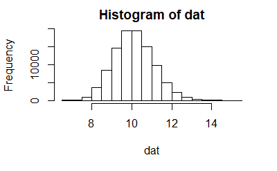

```r
# TODO. ADD a nicer visualization
hist(dat)
```

The summary above correctly shows that the mode is near 10, as we specified. And you can check that `sd` is around 1 if you call `sd(dat)`.

Now, let’s use the synthetic data to see if we can let the model learn the parameters `mode` and `sd`. The code below takes the model that we defined and the (synthetic) data to learn the two parameters. The algorithm that we use here is called MCMC (or Gibbs sampling more specifically). We will talk more about MCMC in the future tutorial.

Notice that we are we have a line that says `parameters <- c("shape", "rate", "mode", "sd")`. This line allows us to monitor the parameters that we want to keep an eye on.

```r
model <-
paste("
  model {

    for (i in 1:N) {
      duration[i] ~ dgamma( shape, rate )
    }

    # Parameterizing the above gamma distribution using
    # mode and sd (standard deviation)

    shape <- 1 + mode * rate
    rate <- (mode + sqrt( mode^2 + 4 *sd^2 ) ) / ( 2 * sd^2 )

    # Now these parameters are back to random variables.
    mode ~ dunif(0, 100)
    sd ~ dunif(0, 100)
  }
")
model_filename <- "01-jags-intro.jags"
writeLines(model, model_filename)
jags.data <- list(
  duration = dat,
  N = N
)
inits <- function(){
  list()
}
# parameters monitored
parameters <- c("shape", "rate", "mode", "sd")
# MCMC settings
ni <- 10000
nt <- 6
nb <- 5000
nc <- 2
# call JAGS from R
res <- jags(
  jags.data,
  inits,
  parameters,
  model_filename,
  n.chains = nc,
  n.thin = nt,
  n.iter = ni,
  n.burnin = nb,
  working.directory = getwd())
```

[output not shown]

# Result

Now, let’s see the results.

```r
# summarize posteriors
print(res, digits = 3)
```

```
Inference for Bugs model at "01-jags-intro.jags", fit using jags,
 2 chains, each with 10000 iterations (first 5000 discarded), n.thin = 6
 n.sims = 1666 iterations saved
          mu.vect sd.vect     2.5%      25%      50%      75%    97.5%  Rhat n.eff
mode       10.016   0.031    9.955    9.995   10.016   10.035   10.076 1.001  1700
rate       10.579   0.469    9.631   10.278   10.576   10.902   11.482 1.000  1700
sd          0.978   0.022    0.938    0.963    0.978    0.992    1.024 1.001  1700
shape     106.951   4.716   97.404  103.934  106.917  110.105  116.047 1.000  1700
deviance 2787.716   2.134 2785.765 2786.227 2787.101 2788.457 2793.364 1.000  1700

For each parameter, n.eff is a crude measure of effective sample size,
and Rhat is the potential scale reduction factor (at convergence, Rhat=1).

DIC info (using the rule, pD = var(deviance)/2)
pD = 2.3 and DIC = 2790.0
DIC is an estimate of expected predictive error (lower deviance is better).
```

The visualization that is created as you execute the following code is called a trace plot. It visualizes whether the parameters that you are monitoring are converging.

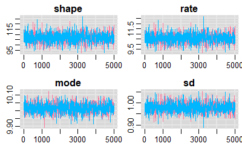

```r
# trace plots
traplot(res, c("shape", "rate", "mode", "sd"))
```

And you can see the sampled parameters of our interest. See that the parameters are close to the true values (e.g., `mode` is near 10 and `sd` is near 1).

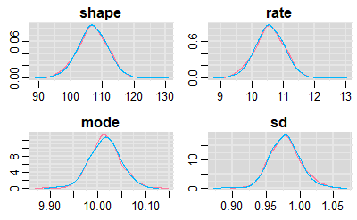

```r
# posterior distributions
denplot(res, c("shape", "rate", "mode", "sd"))
```

# References

- http://doingbayesiandataanalysis.blogspot.com/2012/08/gamma-likelihood-parameterized-by-mode.html
- https://en.wikipedia.org/wiki/Gamma_distribution
- http://www.mbmlbook.com/LearningSkills_A_model_is_a_set_of_assumptions.html